# 04_Luis_Kelly

Kelly Luis

10/2/2018

```r
# Load Libraries
library(dplyr)
```

```r
library(tidyr)
library(ggplot2)
library(beyonce)
```

### 1) W&S Chapter 6 questions 15, 21, and 29

15. For the following alternative hypotheses give the appropriate null hypothesis:
1. Pygmy mammoths and continental mammoths have thes same mean femur lengths.
2. Patients who take phentermine and topiramate lose weight at the same rate as control patients without these drugs.
3. Patients who take phentermine an topiramate have the same proportions of their babies born with cleft palates as patients not taking these drugs.
4. Shoppers on average buy the same amount of candy when Christmas music is playing in the shop as when the usual type of music is playing.
5. The presence or absence of females do not effect the occurence of male white-collared manakins dancing.
21. Imagine that two researchers independently carry out clinical trials to test the same null hypothesis, that COX-2 selective inhibitors (which are used to treat arthritis) have no effect on the risk of cardiac arrest. They use the same population for their study, but one experimenter uses a sample size of 100. Assume that all other aspects of the studies, including significance levels, are the same between the two studies.
1. The 60-participant study has the higher probability of commiting a Type II error because with less samples you have a higher probability of rejecting a false null hypothesis.
2. The 100-particiant study has higher power because it has a lower probability of a random sample leading to the rejection of false null hypothesis.
3. The 100-participant study has the higher proability of commiting a Type I error because with increased samples you have a higher probability of rejecting a true null hypothesis.
4. A one tailed test can be conducted because the alternative hypothesis is that the COX-2 selective inhibitors effect the risk of cardiac arrest and from what I understand we do not care about the significance of the effect (which would then require a two-tailed test)
29. A team of researchers conducted 100 independent hypothesis tests using a significance level of alpha = 0.05:
1. If all 100 null hypotheses are true, what is the probability that the researchers would reject none of them? Pr[0] = 0.0059205
2. If all 100 null hypotheses are true, how many of these tests on average are expected to reject the null hypothesis? Since the significance level is set at 5%, we are expected to reject 5 tests.

### 2) W&S Chapter 7 question 22 - use R to calculate a p-value

22. In a test of Murphy’s law, pieces of toast were buttered on one side and then dropped. Murphy’s law predicts that they will land butter-side down. Out of 9821 slices of toast dropped, 6101 landed butter side down.
1. What is the a 95% confidence interval for the probability of a piece of toast landing butter side down?

```r
# Assign Variables
drop_num <- 9821
but_down <- 6101

# Calculate Proportion
prop_down <- but_down/drop_num

# Calculate Standard Error of Proportion
prop_se <- sqrt((prop_down*(1-prop_down))/but_down)

# Calculate proportion prime for Agresti-Coull Method
prop_prime <- (but_down+2)/(drop_num+4)

# Calculate upper and lower CI bounds
CI_low <- prop_prime - 1.96*sqrt((prop_prime*(1-prop_prime))/(drop_num + 4))
CI_high <- prop_prime + 1.96*sqrt((prop_prime*(1-prop_prime))/(drop_num + 4))

# Sanity Check with Binomial Test
binom.test(x = but_down, p = 0.5, n = drop_num)
```

```
##
##  Exact binomial test
##
## data:  but_down and drop_num
## number of successes = 6101, number of trials = 9821, p-value <
## 2.2e-16
## alternative hypothesis: true probability of success is not equal to 0.5
## 95 percent confidence interval:
##  0.6115404 0.6308273
## sample estimates:
## probability of success
##              0.6212198
```

2. Using the result of part (a), is it plausible to that there is a 50:50 chance of the toast landing butter side down or butter side up? Unlikely because a 50:50 (0.5) chance does not fall in between 0.6115783 and 0.6307627
3. Calculate P-Value

```r
2*pbinom(but_down, size = drop_num, prob = 0.5, lower.tail=FALSE)
```

```
## [1] 6.414273e-129
```

#### 3.1) Start up your simulation

Make a simulated data frame to look at the effects of multiple sample sizes: from 1-20, with 500 simulations per sample size, and also multiple SD values, from 3 through 10 (just 3:10, no need for non-integer values). You’re going to want `crossing` with your intitial data frame of just sample sizes and a vector of sd values to start. Then generate samples from the appropriate random normal distribution.

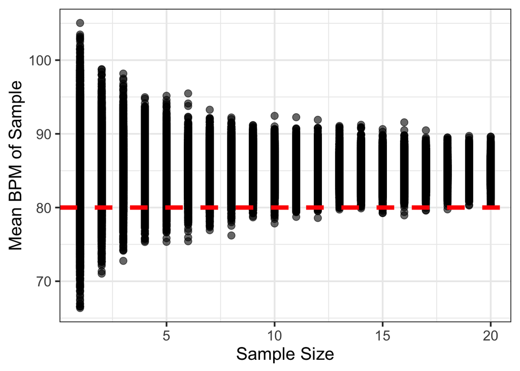

```r
# Assign Variables
pop_mean <- 80
pop_sd <- 6
null_hypo <- 85
power_threshold <- 0.8

# Create Data Frame for Sample Sizes
sim <- data.frame(samp_size = rep(1:20, 500)) %>%
  # Use Crossing for SD vector
  crossing(sd = seq(from = 3, to = 10, by = 1)) %>%
  # Group by Simulation Number
  group_by(sim_num = 1:n()) %>%
  # Generate Random Normal Distribution
  mutate(sample_mean = mean(rnorm(samp_size, null_hypo, pop_sd))) %>%
  ungroup()

# Plot Random Normal Distribution by Sample Size
ggplot(sim) +
  geom_point(alpha=0.6, size=3, mapping=
  aes(x=samp_size, y=sample_mean)) +
  theme_bw(base_size=17) +
  xlab("Sample Size") + ylab("Mean BPM of Sample") +
  geom_hline(yintercept=80, color="red", lty=2, lwd=2)
```

#### 3.2) Z!

OK, now that you’ve done that, calculate the results from z-tests. Plot p by sample size, using `facet_wrap` for different SD values.

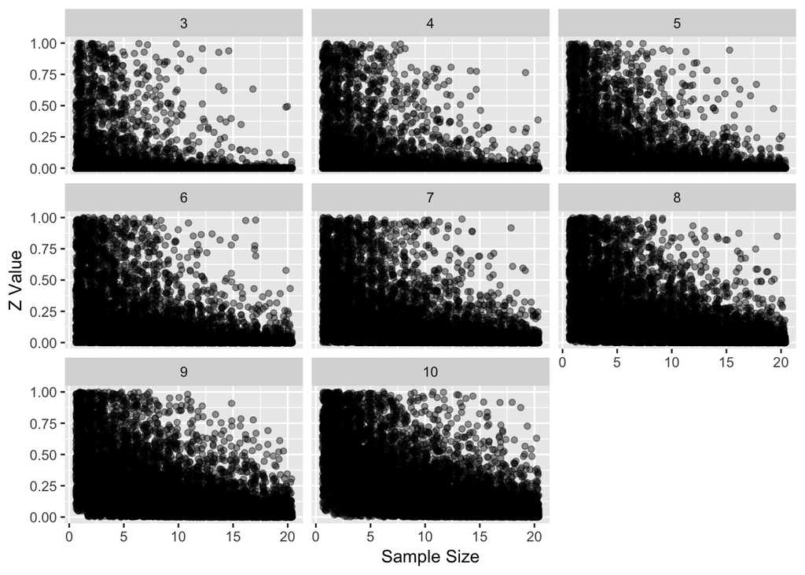

```r
sim_z <- sim %>%
  # Calculate Z
  mutate(z = (sample_mean-pop_mean)/(sd/sqrt(samp_size))) %>%
  # Calculate P
  mutate(p = 2*pnorm(abs(z), lower.tail=FALSE))

# Plot p by sample size for different SD values
  ggplot(data = sim_z, mapping = aes(x=samp_size, y=p)) +
    geom_jitter(alpha = 0.4) +
    facet_wrap(~sd) +
    xlab("Sample Size") +
    ylab("Z Value")
```

#### 3.3) P and Power

Now plot power for an alpha of 0.05, but use color for different SD values. Include our threshold power of 0.8.

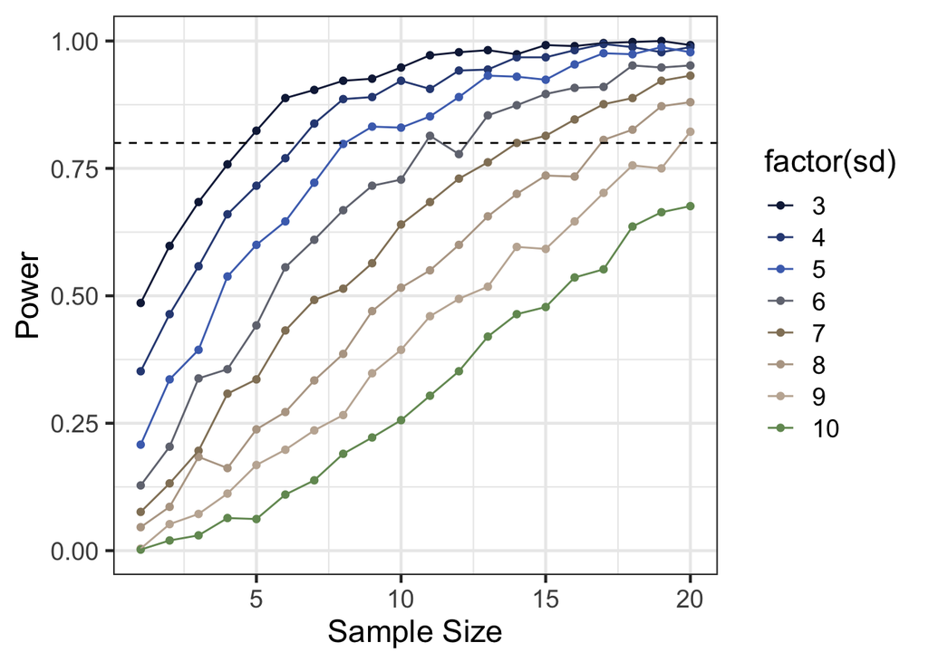

```r
# Calculate power for an alpha of 0.05 for each SD value
sim_power <- sim_z %>%
  group_by(samp_size,sd) %>%
  summarise(power = 1-(sum(p>0.05)/n())) %>%
  ungroup()

# Plot Power for an alpha of 0.05
ggplot(sim_power) +
  aes(x = samp_size, y = power, color = factor(sd)) +
  geom_point() + geom_line() +theme_bw(base_size=17) +
  # Include threshold power of 0.8
  geom_hline(yintercept=power_threshold, lty=2) +
  #scale_color_discrete(name = "SD") +
  scale_color_manual(values = beyonce_palette(82)) +
  xlab("Sample Size") +
  ylab("Power")
```

#### 3.4) Many alphas

Last, use `crossing` again to explore changing alphas from 0.01 to 0.1. Plot power curves with different alphas as different colors, and use faceting to look at different SDs.

```r
sim_alpha <- sim_z %>%
  # Combine vector of alphas from 0.01 to 0.1 with simulation data
  crossing(alpha = seq(from = 0.01, to = 0.1, by = 0.01)) %>%
  #Calculate power for each alpha
  group_by(samp_size, sd, alpha) %>%
  summarise(power = 1-sum(p>alpha)/n()) %>%
  ungroup()
```

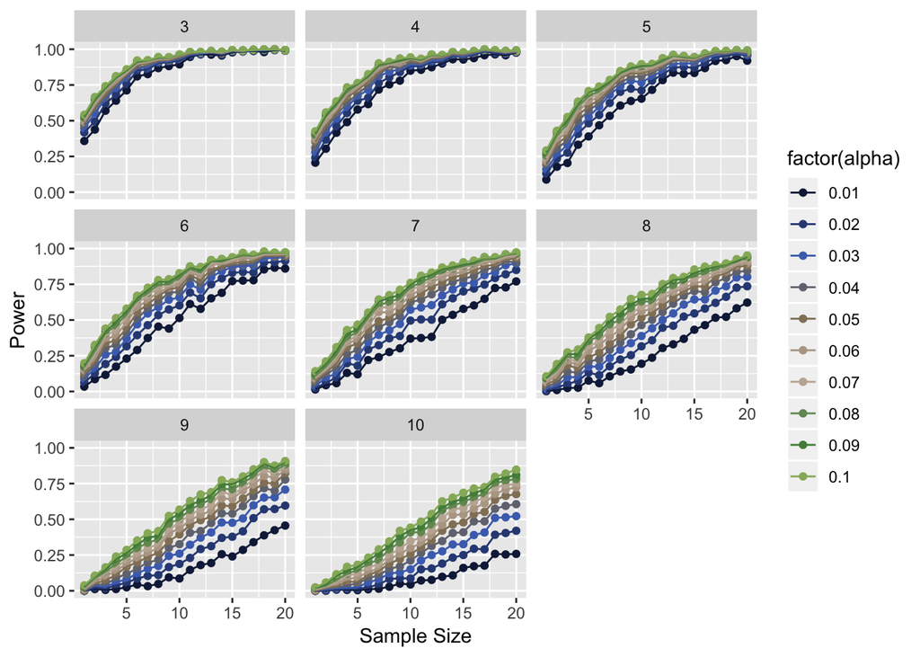

```r
ggplot(sim_alpha) +
  aes(x=samp_size, y=power, color=factor(alpha)) + facet_wrap(~sd) +
  geom_point() + geom_line() +
  xlab("Sample Size") +
  ylab("Power") +
scale_color_manual(values = beyonce_palette(82))
```

```r
#scale_color_discrete(guide = guide_legend(title=expression(alpha)))
```

#### 3.5) What does it all mean? What do you learn about how alpha and SD affect power?

We know that increasing our sample size and increasing our alpha value increases the power of our test, but increasing SD decreases our power.

#### 3.6) How do you think that changing the effect size would affect power?

You can just answer this without coding out anything. Based on what we’ve learned so far - what do you think? The effect size is the standardized mean difference between the control and experimental group. Thus, I think increasing the effect size our power increases because increased effect size is the result of lower SD.